# Regression to the mean in pre-post tests of learning gains among pre-test quartiles

Jeffrey A. Walker

10/14/2021

Source article: [Laboratory Courses with Guided-Inquiry Modules Improve Scientific Reasoning and Experimental Design Skills for the Least-Prepared Undergraduate Students](https://www.lifescied.org/doi/full/10.1187/cbe.18-08-0152)

The results in the source article appear to be entirely due to regression to the mean and not due the the poor performers learning more, as argued by the authors. What is regression to the mean?

# Regression to the mean

Unless a student knows the answer to every question on an exam, there is a stochastic component on an exam score due to guessing. If a student were to take an exam many times, each time just randomly guessing an answer for the unknown questions, the score would be unusually high on some exams, because the student was unusually lucky on a large fraction of the guesses, and the score would be unusually low on some exams, because the student was unusually unlucky on a large fraction of the guesses. In a class full of students taking a single exam, some fraction are unusually lucky and their exam scores make them appear smarter than their actual knowledge while some students are unusually unlucky and their exam scores make them appear less smart than their actual knowledge (if the exam score isn’t corrected for guessing, then all students will appear smarter than their actual knowledge but the lucky students will be unusually smarter and the unlucky students will appear barely smarter). The scores of lucky students are shifted up relative to the class. The scores of unlucky students are shifted down relative to the class. This shift due to the stochastic (guessing) nature of multiple choice tests means that the top quartile will gain some students because of good luck and lose some students because of bad luck. This shift means that the bottom quartile will gain some students because of bad luck and lose some students because of good luck. Luck is luck and luck changes randomly. The next time the students take a test, the students with unusually good luck are unlikely to have unusually good luck, and so this stochastic component or shift will almost certainly be less “up”. Likewise, the students with unusually bad luck are unlikely to have unusually bad luck again, and so this stochastic component or shift will almost certainly be less “down”. Students with unusually good luck on test 1 will appear to have done worse on test 2 and students with unusually bad luck on test 1 will appear to have done better on test 2, even if nothing has changed. This phenomenon is **Regression to the Mean**.

# Create fake data

It’s easy to simulate regression to the mean to pump our intuition. In this simulation, there are 100 students that take a test twice. The first time is “pre” the second time is “post”. There is a correlation between pre and post scores. Students that score higher on test 1 tend to score higher on test 2.

This correlation between pre and post controls the amount of regression to the mean. As the correlation goes from 0 to 1, regression to the mean goes to zero. A correlation of 0 would occur if all students are guessing every question, so the scores are entirely random. A correlation of 1 would occur if the fraction of correct guesses for each student is the same on the pre-test and the post-test. This won’t happen but higher correlations would occur on tests with fewer effective choices per question (if a question has 5 possible answers, and 80% of the students choose A and 20% B but none choose C, D, or E, there are effectively 2 choices.)

Regression to the mean is independent of success of learning. In the article, the estimate of the effect of teaching was effectively zero (the measured value was slightly negative). Learning will just shift all the points on the up the y axis of either the scatterplot of post vs. pre scores or the strip chart of change vs. quartile, but it won’t change the regression to the mean because regression to the mean is a function of the stochastic component of a test score (the guessing).

In this simulation, there is zero difference in learning between those in the lower or upper quartile. But regression to the mean creates the appearance of a difference because a component of the lower scores is stochastic and a component of the high scorers is stochastic.

```r
# parameters to control
n <- 100
r_pre_post <- 0.6
effect_of_teaching <- 5

beta <- sqrt(r_pre_post)
z <- rnorm(n, mean = 0, sd = 1)

fake_data <- data.table(
  pre = beta*z +
    sqrt(1 - r_pre_post)*rnorm(n, mean = 0, sd = 1),
  post = beta*z +
    effect_of_teaching +
    sqrt(1 - r_pre_post)*rnorm(n, mean = 0, sd = 1)
)
 fake_data[, change := post - pre]
# cor(fake_data$pre, fake_data$post)

 ggscatter(data = fake_data,
           x = "pre",
           y = "post")
```

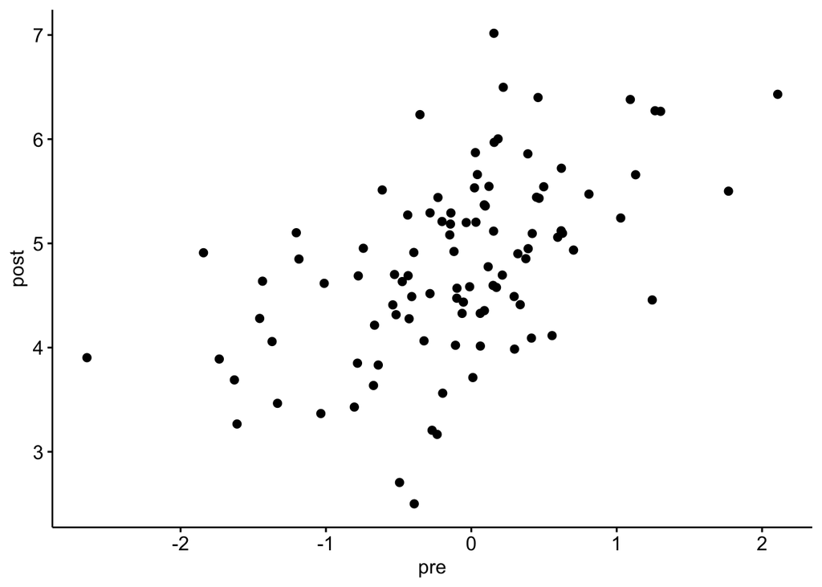

## Because of regression to the mean, change scores will be negatively correlated to pre-test scores if there is a stochastic component to test score (guessing)

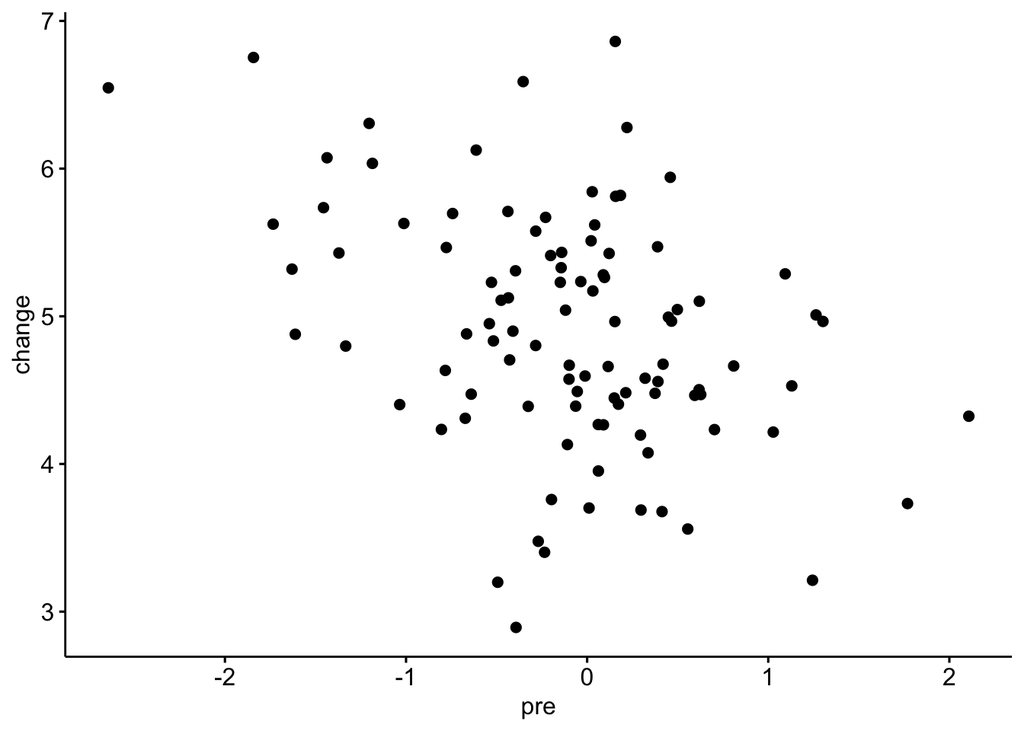

```r
ggscatter(data = fake_data,
           x = "pre",
           y = "change")
```

## Because of regression to mean, the lowest quartile will appear to have gained the most and highest quartile will appear to have gained the least. If the average gain is near zero, then the highest quartile will appear to have lost knowledge. This is what occured in the focal article.

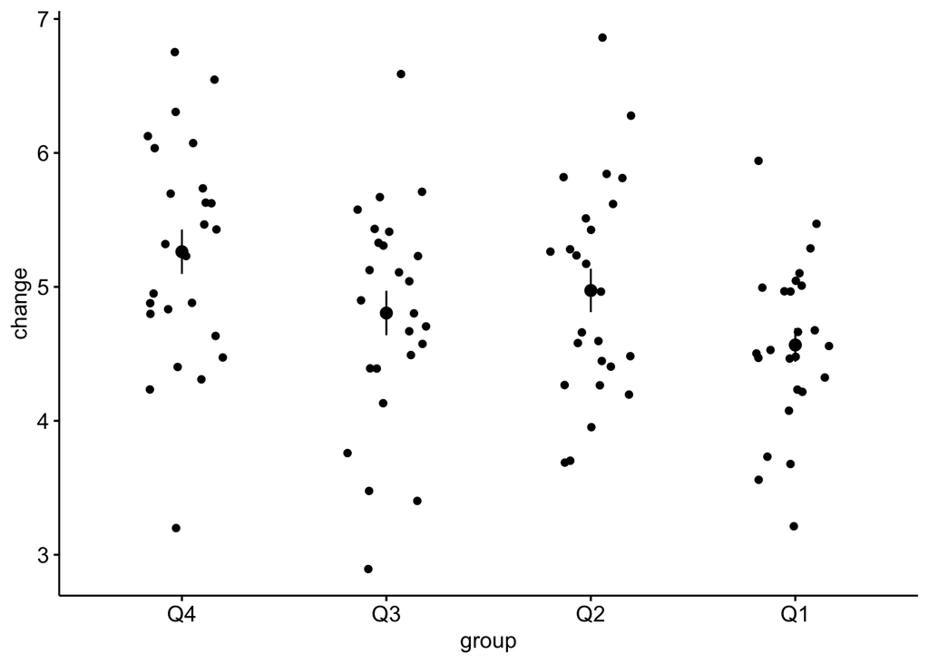

```r
quartiles <- quantile(fake_data$pre, c(0.25, 0.5, 0.75))
fake_data[pre <= quartiles[1],
          group := "Q4"]
fake_data[pre > quartiles[1] & pre < quartiles[2],
          group := "Q3"]
fake_data[pre > quartiles[2] & pre < quartiles[3],
          group := "Q2"]
fake_data[pre > quartiles[3],
          group := "Q1"]

fake_data[, group := factor(group,
          levels = c("Q4", "Q3", "Q2", "Q1"))]

ggstripchart(data = fake_data,
          x = "group",
          y = "change",
          add = c("mean_se"))
```